# Connecticut’s 2016 Presidential Campaign Finance

## Introduction

In this exploratory analysis we’re going to look at Connecticut’s contributions to the 2016 Presidential elections and see what the data provided by the [Federal Election Comission](https://classic.fec.gov/disclosurep/pnational.do) might tell us about Connecticut’s population. There are no information goals in mind at the moment for this dataset, it hasn’t even been looked at, to facilitate a “stream of consciousness” approach as requested.

Outputting a sample of some of the information in the dataset:

```
##         cmte_id   cand_id                 cand_nm            contbr_nm
## 23196 C00575795 P00003392 Clinton, Hillary Rodham      RIETZE, SHIRLEY
## 80065 C00575795 P00003392 Clinton, Hillary Rodham        KARPIE, KAREN
## 52936 C00575795 P00003392 Clinton, Hillary Rodham        TAYLOR, DAVID
## 75514 C00575795 P00003392 Clinton, Hillary Rodham      EDELMAN, BONNIE
## 12523 C00577130 P60007168        Sanders, Bernard CHRISTMAS, MS. CAROL
##         contbr_city contbr_st contbr_zip       contbr_employer
## 23196       MERIDEN        CT   64505929           MACY'S INC.
## 80065       MILFORD        CT   64603442 MURPHY AND KARPIE LLC
## 52936 WEST HARTFORD        CT   61171404         SELF-EMPLOYED
## 75514    RIDGEFIELD        CT   68771219         SELF-EMPLOYED
## 12523        HAMDEN        CT   65172027      WRITEALETTER.ORG
##       contbr_occupation contb_receipt_amt contb_receipt_dt receipt_desc
## 23196    STOCK PROCURER             19.00        15-MAR-16
## 80065          ATTORNEY            100.00        05-NOV-16
## 52936            ARTIST             25.00        23-MAY-16
## 75514      PHOTOGRAPHER            130.55        28-JUL-16
## 12523    LETTER CARRIER             10.00        29-FEB-16
##       memo_cd                           memo_text form_tp file_num
## 23196                                               SA17A  1081062
## 80065                                               SA17A  1133832
## 52936       X              * HILLARY VICTORY FUND    SA18  1091720
## 75514       X              * HILLARY VICTORY FUND    SA18  1109498
## 12523         * EARMARKED CONTRIBUTION: SEE BELOW   SA17A  1077916
##           tran_id election_tp NA
## 23196    C3411635       P2016 NA
## 80065   C15460769       G2016 NA
## 52936    C5584211       P2016 NA
## 75514    C8556443       G2016 NA
## 12523 VPF7BK8YS86       P2016 NA
```

Unique volumn values:

```
##           cmte_id           cand_id           cand_nm         contbr_nm
##                24                24                24             21766
##       contbr_city         contbr_st        contbr_zip   contbr_employer
##               385                 1             12890              7549
## contbr_occupation contb_receipt_amt  contb_receipt_dt      receipt_desc
##              4285              2624               654                21
##           memo_cd         memo_text           form_tp          file_num
##                 2                72                 3               168
##           tran_id       election_tp              <NA>
##            107435                 6                 1
```

## Basic Information and Distrobution plots

This dataset contains 107,560 observations, or rows of data, with 19 variables. At least half the dataset is fairly useless though, with columns of data like ‘candidate id’ - we have their names as unique identifiers, and the list goes on - a binary ‘memo to charitable donations’ column, form type, file number, receipt description, and transaction ID. None of these columns can really add much to the finacial aspect of this dataset and they will be dropped.

Let’s take a look at the the most basic aspect of the dataset and why we’re here: how much money was given to each candidate!

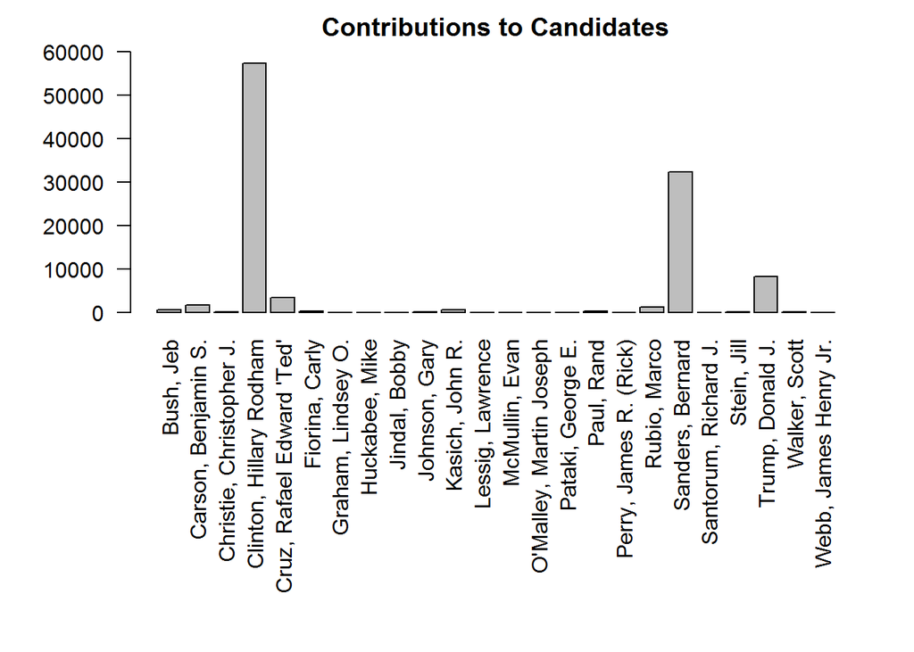

Clearly Clinton, Sanders, and Trump had the majority of the contributions in the state. We’re going to focus further explorations on just the three of them. I’m not a very partisan individual, but I was still surprised to see Sanders exceeded Trump in the elections, not because I didn’t think Connecticut was a left leaning state, I knew it was, but because no one talks about Bernie here; where as I know a vast number of people who support Trump. This will be a comparative note going forward.

Number of votes after reduction:

```
## [1] 98188
```

Perceentage of voters this represents in Connecticut:

```
## [1] 91.28672
```

Reducing the dataset down to these three candidates will not affect the outcome of any further analysis. Let’s look at the same graph as above with only these candidates:

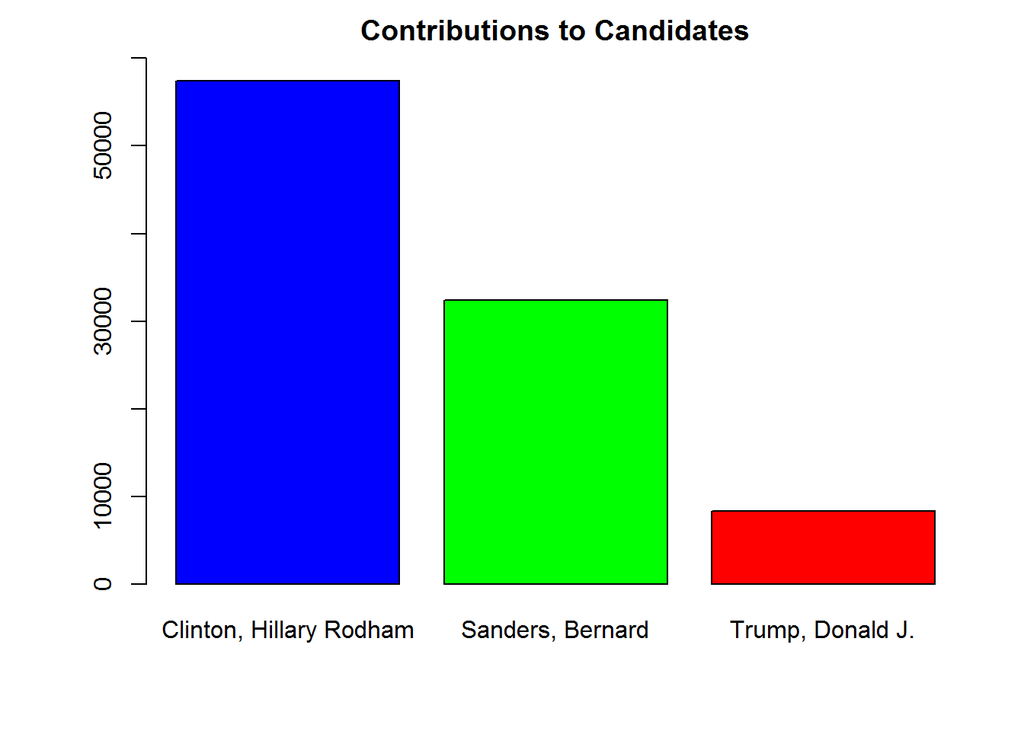

## When, Where, and Who Are Citizens Contributing?

I still find it interesting that Bernie received more contributions in CT than Trump, lets take a look at when these candidates received their contributions to get a better idea.

### When

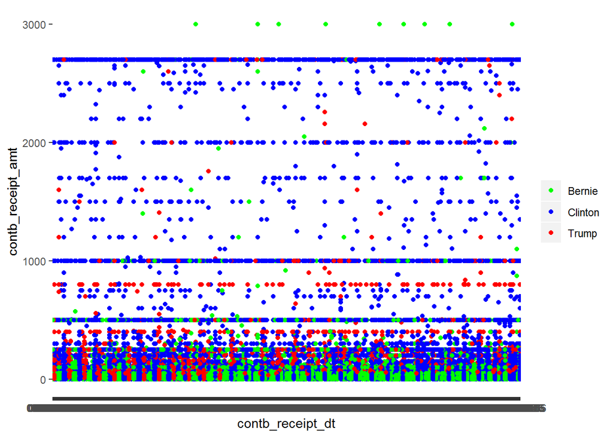

Bernie wound up losing to Hillary but the state still loves him I guess. So [respectful](https://www.nhregister.com/connecticut/article/In-Connecticut-Hillary-Clinton-beats-Bernie-11330502.php#photo-13317210) when they want to be.

Bernie definitely has the most sporadic investment coming in, with Trump close behind, altough he did have some strong low to mid level support that was pretty regular. Clinton on the other hand had money coming all the time, and lots of it.

### Where

Next I’d like to see who in the state was contributing to each candidate by location, we’ll break down total number of contributions for each candidate by county.

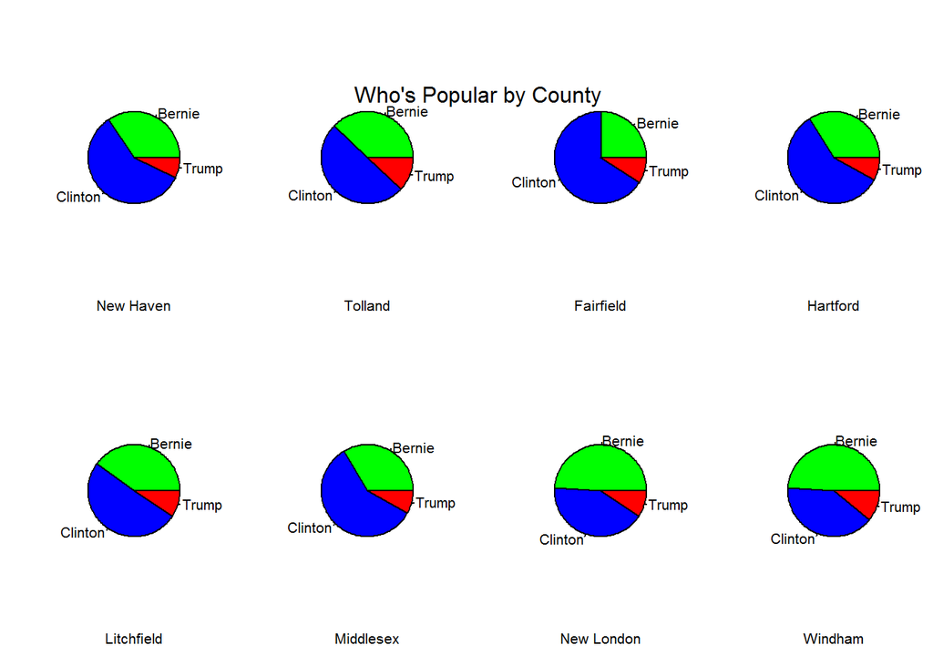

The only clearly overwhelming favorability in a county is Fairfield, which clearly supports Clinton. The only counties where Clinton didn’t have at least half the contributions was New London and Windham. I don’t recognize them as the socialists they clearly are but at least they gave Bernie a little bumper sticker love, seeing as how they don’t actually have any money there to conribute.

Fairfield County is the only one that’s close to the 3/4 mark for contributions to a single candidate. I’m guessing they also contributed the most money (overall, amonst any county), seeing as how it’s the most affluent area of the state, lets take a look at that data next.

[figure not shown]

### What

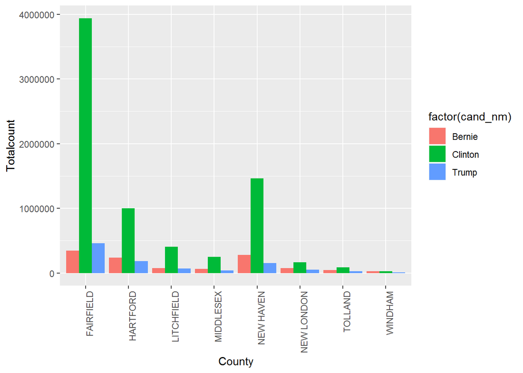

First off, I apologize for the color difference in the key for this graph, I used ‘ggplot’ above and was above to sort the colors how I wanted but it will not response this time no matter what I’ve tried. I guess for this one it works, green is for money and Clinton’s swimming in it!

This ridiculous difference in scale may look surprising to those outside New England but, with out digging especially deep, it’s not at hard to believe being a CT native. Fairfield County is one of the richest counties in the country, not just CT or New England. We’re talking “the top 2%” kind of money here. Honestly I didn’t think it would be quite that much more, but I’m really not surprised.

Some other notes about the graph, not surprising New Haven County would be second. A good chunk of the state’s population lives here, and speaking from experience (I live in the city of New Haven), it’s an actively political area to say the least. People are vary passionate about voting in the city of New Haven, and it’s very liberal.

Seeing some large drop off in money contribution in counties like New London, Tolland, and Windham are not surprising - no one lives there!

[interactive chart not shown]

## Summary

For me the most telling plot was the second to last, because it contains a lot of information about contributions made during the 2016 elections like the total dollar amount given to each candidate and from where the money is coming from - showing the supporters by location. Below is an alternate version of that graph, where I’ve added the election period. It’s interesting to note here that after the primary elections the majority of financial support from the state went to Clinton. Bernie was out and Trump only received a fraction of what Clinton got, keeping in line with Connecticut being a liberal state overall the last several years.

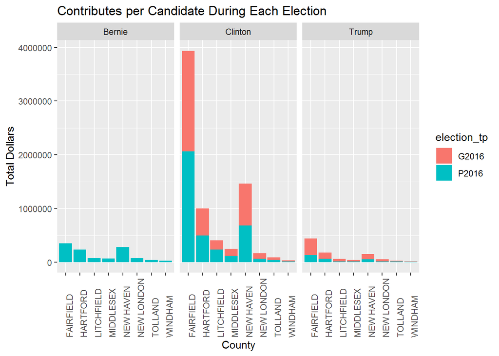

## Reflections

This dataset was relatively unsurprising. The 2016 elections were highly broadcast and most people living in more urban environments at least had an idea of what was going on. It was interesting to see from the data, and from a financial perspective, the trend of the money flow with Bernie and Clinton being the fore-runners about halfway through, but then seeing Bernie fade out and the continued support of Clinton through until the general elections.

Some challenges working with this dataset was I didn’t find it very interesting, and normally this type of information is to me. I found there not to be a lot of relevent data that you could really explore and manipulate. I did do some quick Google searches to see if I could find more data to expand this set, but there wasn’t really much specifically for CT that would have been useful. Grabbing another table that contained the counties was helpful though, it’s much easier to look at 8 breakdowns to separate the area rather than the 300+ towns to try and get a geographical perspective. I also found working with R to be cumbersome. Admittedly this was my first time using it, but I find the language to not be as intuative as Python and the support online (from sites like stackoverflow etc) to not be nearly as explanatory as for Python. I’m glad this is the only project requiring the use of R.